A Cluster Analysis of the Minnesota Timberwolves Matt Parker parke898@umn.edu

[figure not shown]

# Introduction

As the Timberwolves embark on what could possibly be their best regular season in franchise history, it’s hard not to reminisce on some of the players who brought us joy and anger (mostly anger) in some of our most excruciatingly painful seasons. In fact, I often ponder on the idea of former Wolves and the role they might have played in current iterations of the team. Using a statistical classification method called k-means clustering, we can do just that by grouping similar Wolves players together using various basketball statistics focused on advanced algorithms and player tendencies.

In this project, I’ll be going over the use and implementation of k-means clustering, the data sets and how they were collected / manipulated, and finally the visualization of our k-means cluster plots that split our observations into nine distinct groups.

## Library

# K-Means Clustering: Calculations and Steps for Clustering the Data Set

K-means clustering is an unsupervised statistical method focused on splitting observations into subgroups, where the observations in each subgroup exhibit similarities to each other based on the values of their predictor variables. When we say a statistical method is unsupervised, this implies that there is no response variable present in the data set, so our variables won’t be used to make predictions.

The idea of k-means is to create a set number of clusters so the total within-cluster variation is minimized. The algorithm we’ll use to create our clusters, which is visualized below, is calculated as the sum of squared distances between observations and the mean of observations within each cluster, otherwise known as the centers.

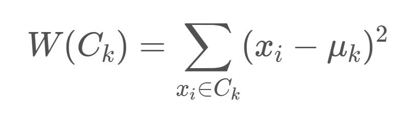

Here, x<sub>i</sub> is defined as a data point within cluster C<sub>k</sub>, while u<sub>k</sub> is the mean of all data points within C<sub>k</sub>. Ultimately our goal is to minimize the total within cluster sum of squares algorithm, visualized below.

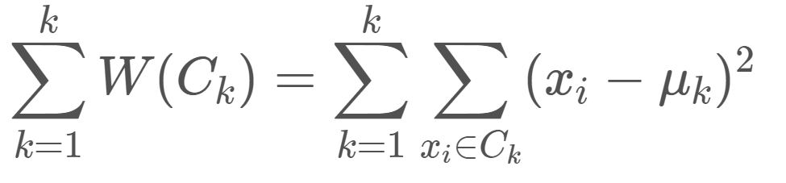

In creating our k-means algorithm, several steps are involved in optimizing statistical performance and minimizing within cluster variation. First off, we initialize the number of clusters to be created, which we define as k. From there, we randomly select k observations from our data set and initialize these points as our cluster centers (or means). We’ll follow by assigning observations to their closest cluster, while updating our cluster centers as new observations are assigned. In our analysis, we will create 25 initial configurations of our model, which is recommended in k-means clustering, and report on the best model.

What we should ideally produce is a set number of clusters where our observations, or in this case our players, have similar playing styles and player performance based on their statistics encompassed over a single season of play. Ultimately, some players may be placed in clusters that don’t necessarily align with our perceived notion of their performance, since we’re only considering x number of statistics that have various flaws in their own right. With that said, our k-means clusters should produce some fun visuals that highlight similarities that various Wolves players exhibited over the years.

# The Dataset

Our data set will encompass all Minnesota Timberwolves players who have played a minimum of 500 minutes in a season since 2012-2013. I wanted to create a relatively large data set while including only those players who made an impact on the floor (bad or good), and 500 minutes felt like the appropriate cutoff for that description. Though 138 individual player seasons were included in the data set, 63 of those come from unique players, so it’s worth noting that there will be duplicates of players from different seasons.

The player statistics were taken from Basketball Reference, using basic and advanced stats tables from 2012 up until 2024. The data sets used in analysis were wrangled together using MySQL, which involved joining basic and advanced stat tables together and eliminating all variables that wouldn’t be present in analysis outside of player names, seasons, and minutes played. The data was then exported to R where I began my analysis.

## Variables

### Tendency Statistics

- 3PAr – 3-Point Attempt Rate: Percentage of FG Attempts from 3-Point Range
- FTr – Free Throw Attempt Rate: Number of FT Attempts Per FG Attempt
- ORB% – Offensive Rebound Percentage: An estimate of the percentage of available offensive rebounds a player grabbed while they were on the floor.
- DRB% – Defensive Rebound Percentage: An estimate of the percentage of available defensive rebounds a player grabbed while they were on the floor.
- AST% – Assist Percentage: An estimate of the percentage of teammate field goals a player assisted while they were on the floor.
- STL% – Steal Percentage: An estimate of the percentage of opponent possessions that end with a steal by the player while they were on the floor.
- BLK% – Block Percentage: An estimate of the percentage of opponent two-point field goal attempts blocked by the player while they were on the floor.
- TOV% – Turnover Percentage: An estimate of turnovers committed per 100 plays.
- USG% – Usage Percentage: An estimate of the percentage of team plays used by a player while they were on the floor.

### Advanced Statistics

- WS/48 – Win Shares Per 48 Minutes: An estimate of the number of wins contributed by a player per 48 minutes (league average is approximately .100)
- OBPM – Offensive Box Plus/Minus: A box score estimate of the offensive points per 100 possessions a player contributed above a league-average player, translated to an average team.
- DBPM – Defensive Box Plus/Minus: A box score estimate of the defensive points per 100 possessions a player contributed above a league-average player, translated to an average team.
- VORP – Value over Replacement Player: A box score estimate of the points per 100 TEAM possessions that a player contributed above a replacement-level (-2.0) player, translated to an average team and prorated to an 82-game season.

In conducting my analysis, I was looking for a set of variables that would account for play style as well as player performance. I decided not to include basic counting stats like points, rebound, assists, etc so we could more easily compare players who play significant minutes and those who don’t, while instead opting for a collection of advanced stats to quantify performance. These advanced metrics are far from perfect, so keep that in mind when considering how each player is categorized.

Tendency stats should provide a glimpse into how players can be categorized into specific overarching play styles. For example, Luke Ridnour and Nikola Pekovic may exhibit similar advanced numbers quantifying performance, but they’re on opposite sides of the spectrum when it comes to their style of play. These statistics should assist in categorizing players who play similar styles of basketball. In addition, I believe tendency stats aren’t significantly swayed by volume, or in this case minutes played, as players tend to play the same style of basketball no matter how often they see the court.

## Data Manipulation

Below is our complete set of unique Timberwolves players who have logged at least 500 minutes in a season since the 2012, with the code for filtering the data set here[^1].

| Kevin Love | Andrei Kirilenko | Nikola Pekovic | Luke Ridnour | Ricky Rubio |
| --- | --- | --- | --- | --- |
| Dante Cunningham | Derrick Williams | Alexey Shved | J.J. Barea | Chase Budinger |
| Greg Stiemsma | Corey Brewer | Kevin Martin | Gorgui Dieng | Luc Mbah a Moute |
| Robbie Hummel | Ronny Turiaf | Andrew Wiggins | Zach LaVine | Thaddeus Young |
| Mo Williams | Anthony Bennett | Shabazz Muhammad | Adreian Payne | Lorenzo Brown |
| Karl-Anthony Towns | Tayshaun Prince | Nemanja Bjelica | Tyus Jones | Kevin Garnett |
| Kris Dunn | Brandon Rush | Taj Gibson | Jeff Teague | Jimmy Butler |
| Jamal Crawford | Josh Okogie | Dario Saric | Derrick Rose | Anthony Tolliver |
| Robert Covington | Jerryd Bayless | Keita Bates-Diop | Jarrett Culver | Shabazz Napier |
| Treveon Graham | Jordan McLaughlin | Jake Layman | Anthony Edwards | Jaden McDaniels |
| Naz Reid | Malik Beasley | D’Angelo Russell | Jarred Vanderbilt | Juancho Hernangomez |
| Jaylen Nowell | Patrick Beverley | Taurean Prince | Rudy Gobert | Kyle Anderson |
| Austin Rivers | Mike Conley | Nickeil Alexander-Walker |  |  |

One additional note to keep in mind is on turnover percentage (TO%). Without making any changes to the data set, a player with a low turnover percentage would have a scaled TO% value below zero. Considering a low turnover percentage is a positive for player performance, I decided to change the TO% values to negative values to flip them across the mean. In doing so, players with low turnover percentages will now have positive scaled values.

# K-Means Clustering: Algorithm and Optimal Number of Clusters

Before we develop our k means algorithm, we must determine the optimal number of clusters for analysis. In doing so, we will calculate our clustering algorithm at a specific value of k, with k being the number of clusters, and determine the within cluster variation at each value of k. We’ll then plot each within cluster variation value and determine the optimal number of clusters using this plot. Usually, we choose the number of clusters where the decrease in within cluster variation is minimal or there is a noticeable elbow in the plot. Below is our plot for cluster optimization, where I ultimately choose nine as the ideal number of clusters.

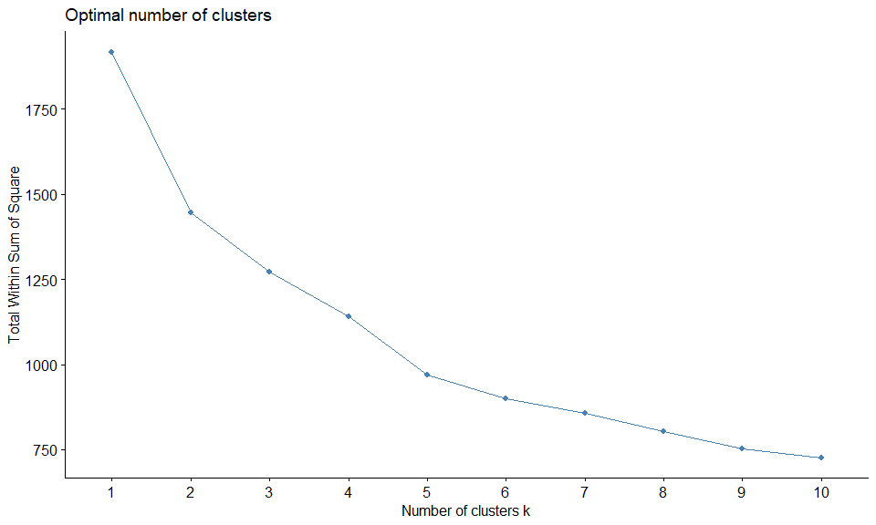

# Visualizing K-Means Clusters

Finally, our analysis and visualization. I created a for loop that would visualize all nine clusters and the players present within each cluster. For the sake of a cleaner visual, I decided to put the centers (or means) of each variable in descending order to highlight the skills that the players in each cluster excelled in, or didn’t excel in. This means that the variables on the x axis won’t be in the same order across plots, so keep that in mind when analyzing the plots. In addition, I created an if statement within the loop to remove duplicate names if a cluster exceeded 15 player seasons to avoid overfilling the tables. For example, cluster one will have duplicate players, while cluster three won’t due to the number of players present in the cluster.

Below are the visuals of all 9 clusters, labeled by what I determined to be a proper group name given their cluster centers and the players present (but it’s up for interpretation!). What you’ll see is the average value of each statistic, scaled to the rest of the data set, for all players present in the cluster.

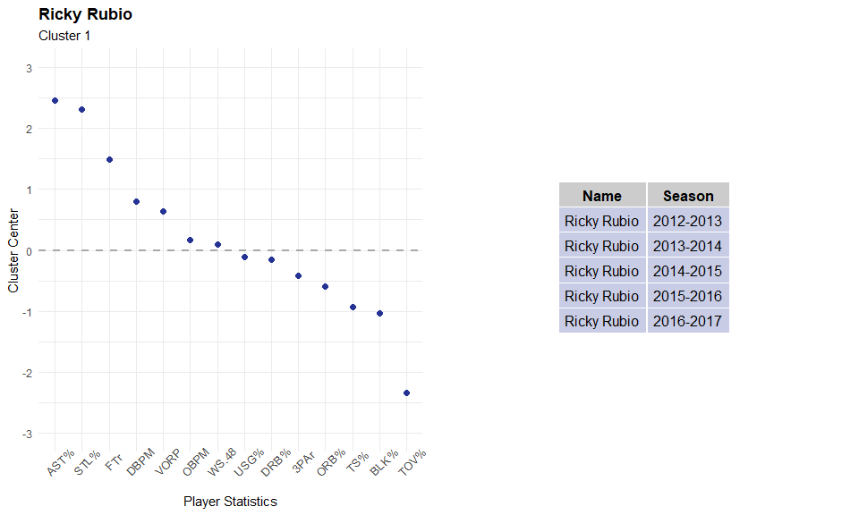

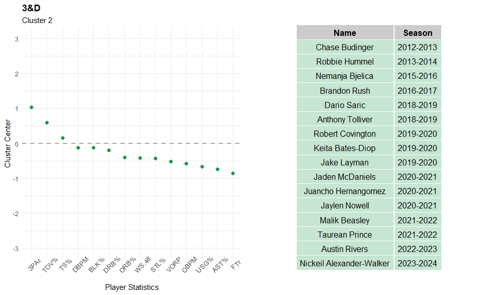

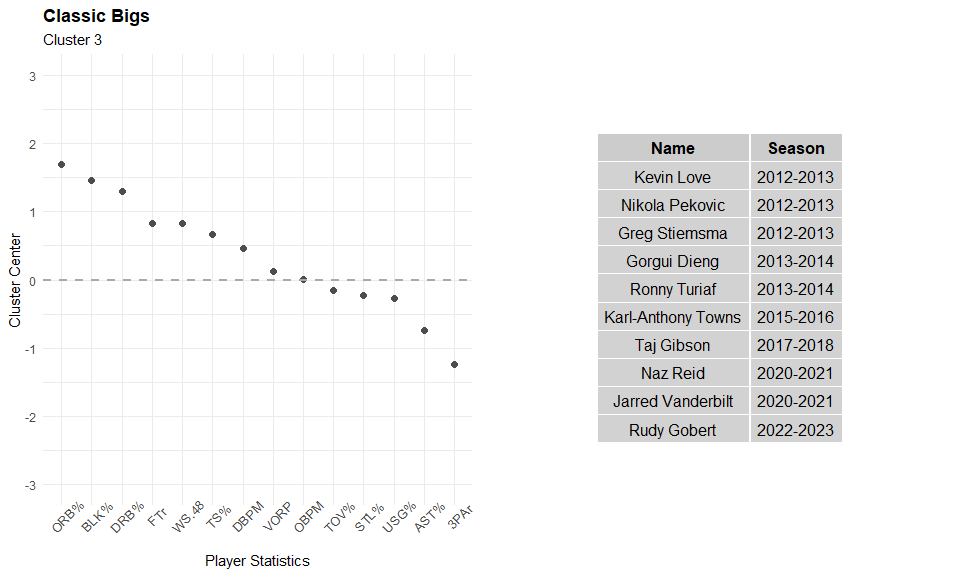

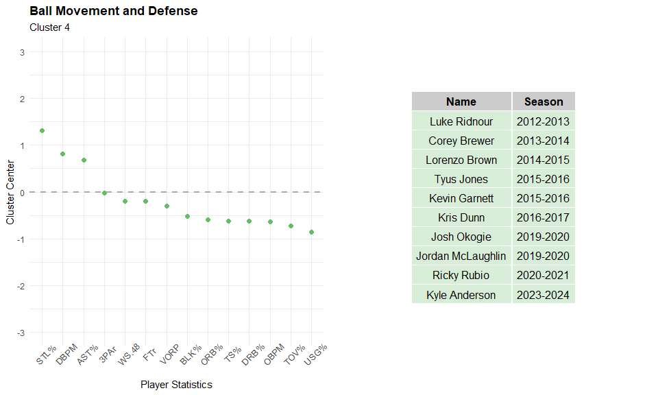

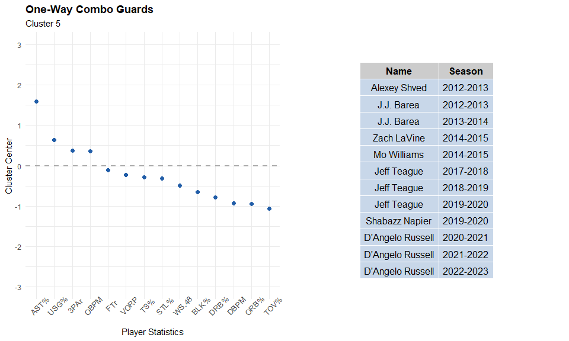

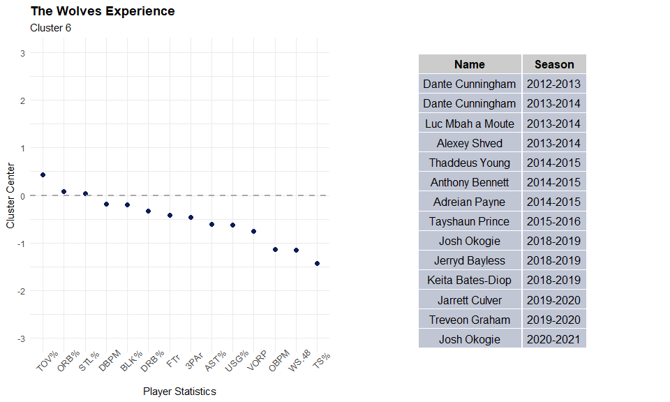

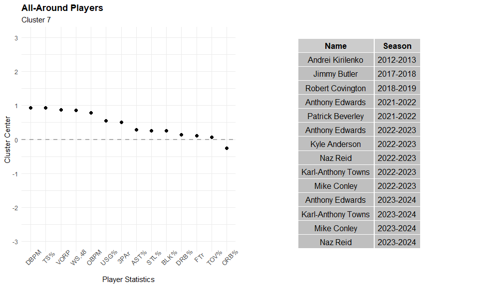

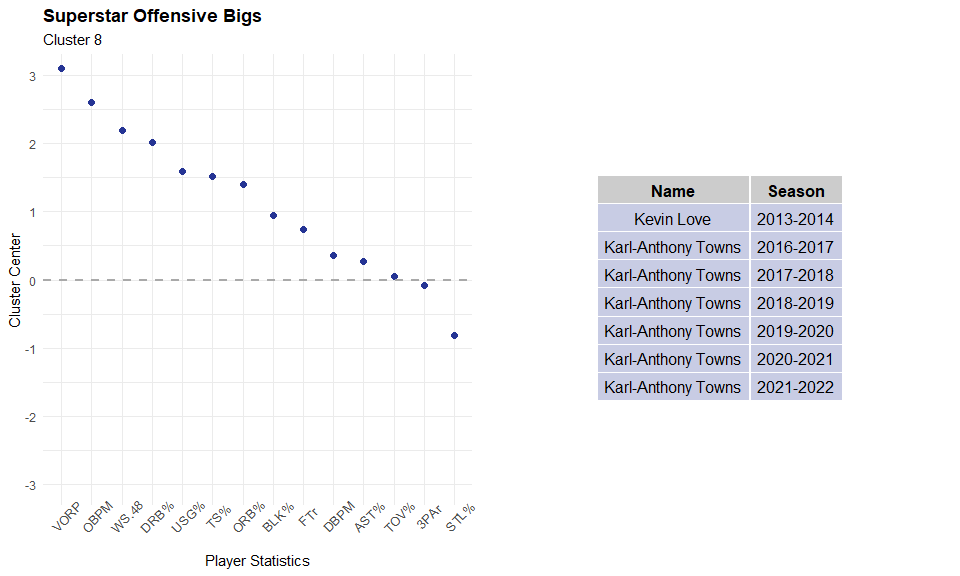

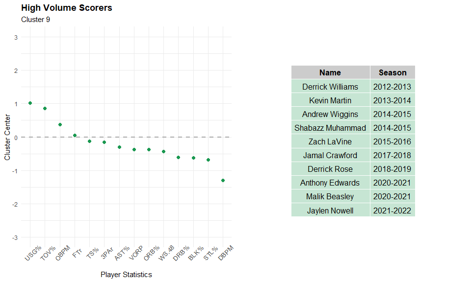

# Predicting New Observations: Monte Morris

Lastly, I wanted to take a look at recently acquired point guard Monte Morris, with the goal of comparing his career numbers to the nine clusters created in our k-means algorithm. I collected Monte’s career numbers and scaled them relative to the rest of our database.

From there, I calculated the sum of square differences between Monte’s numbers and the cluster centers within each cluster. Below is a table containing these sum of square differences between Monte and all nine clusters.

| 1 | 2 | 3 | 4 | 5 | 6 | 7 | 8 | 9 |
| --- | --- | --- | --- | --- | --- | --- | --- | --- |
| 5.92 | 2.62 | 5.2 | 3.46 | 3.33 | 3.86 | 3.06 | 6.67 | 2.9 |

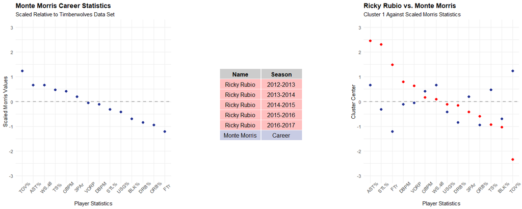

[^1]: [Link to the R Script](https://github.com/MattP2232/STAT4052-Project/blob/main/R%20Code/4052%20Final%20Project.Rproj)